# Los puentes de la experiencia: abducción, enacción y creatividad

Autor/a

Afiliación

Francisco Matías Schaer

Universidad de Buenos Aires - Universidad Nacional de las Artes

# Introducción

Imaginemos *tener* una carta para guardar en un sobre. No conocemos la medida *exacta* de la carta ni la del sobre, sólo podemos inferir hipotéticamente que podría entrar o no a partir de evaluar distancias, superficies, la profundidad del sobre, y luego de unos momentos, *razonar* cuántos pliegues necesitamos para poder introducirlo, sin arrugar el papel. La capacidad de ajustar el tamaño del papel doblado al espacio interno del sobre parece una idea sencilla, pero depende de las dimensiones del papel a doblar, de la cantidad y la calidad de operaciones (semejantes entre sí o no) que imaginamos necesarias para lograr el objetivo. También, quizás, del hábito de doblar cartas, de conocer ciertas reglas.

En esta traducción hipotética entre dos magnitudes analógicas requerimos una idea de *forma posible*, imaginamos que se requiere una *figuración icónica* del papel doblado como posibilidad de ajustarse al tamaño requerido, algo que *ordene* alguna exteriorización posible. En términos de resultado, luego de realizar los pliegues observaríamos si efectivamente era posible o no en función del recorrido que elegimos.

Figura Nº1. Cómo doblar una carta según tipo de papel.

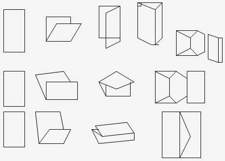

Resultado de imagen para como doblar una carta

Este evento descripto, desde la perspectiva de Niklas Luhmann, implicaría poner en juego distintos observadores. El agente que imagina, calcula y realiza la operatoria, constituye el observador de primer grado, pero también podrían existir observadores de segundo grado, que a su vez, califican y analizan este evento mínimo. Desde ese plano, se podrían realizar hipótesis sobre la naturaleza de la "carta", la motivación y la situación. Se elaborarán conjeturas sobre los nervios de aquel agente, si está o no facultado, siendo consciente que es observado por alguien. Sobre esta hipótesis, un observador de tercer grado podrá distinguir las formulaciones iniciales, desde una posición (ficticia) inercial: el paisaje de lo "observado" se corresponde o no a lo inferido, a lo *percibido* "socialmente", indagará y podrá construir esquemas de relaciones. Así, el proceder por “distinciones” encapsula el fenómeno en reduccionismos, fijando un determinismo sobre la “distinción”, abandona el interrogante sobre el origen y el trayecto de las interacciones entre los sistemas y entornos. ¿Doblar una carta es construir posibilidades en las posiciones de observación sobre el objeto, observadores según lados? ¿*Creen* los observadores? ¿En qué creen?

Según Luhmann, el observador, para generar la diferencia entre espacio-con-marca y espacio- sin-marca, y para distinguirse a sí mismo de lo que señala, debe utilizar una distinción. La distinción sirve tan sólo (y ésta es su intención) para designar algo como distinto de otra cosa." Desde el punto de vista que se adopta en este trabajo, el trazado de "distinciones" no es otra cosa que un *discurso sobre la acción para legitimar la observación*, y al definir la observación como acción; cancela y niega la ecuación. La *distinción*, situado del lado de una fenomenología, se derrumba como concepto al admitir que el observador humano no es una excepción[^1]. ¿Si no soy *capaz* de establecer distinciones, no estoy observando? ¿Si me muevo en el espacio estoy "marcándolo"? ¿Cuál es el grado de observación *mía* con respecto a mi propio cuerpo? Si es así, ¿qué observadores de segundo y tercer orden sabrán qué significan *mis* movimientos, si ello fuera posible? ¿Cuál será su distancia con su propio observador de primer grado? Si permanentemente estoy generando distinciones ¿qué es una distinción de grado?

Tanto Francisco Varela como Eliseo Verón, se han diferenciado en distintos textos del enfoque de Luhmann. Si bien se trata de perspectivas con puntos de partida en disciplinas distintas, resulta de interés analizar brevemente de qué modo se diferenciaron del autor. En el prefacio del libro “De máquinas y seres vivos”, en su segunda edición, Francisco Varela advierte sobre los usos de la “autopoiesis” en otras disciplinas.

> (…) “En la idea de autopoiesis las nociones de red de producciones y de frontera tiene un sentido más o menos preciso. Cuando la idea de una red de procesos se transforma en”interacciones entre personas”, y la membrana celular se transforma en el “borde” de un grupo humano, se incurre en un uso abusivo, como lo expresé en un comentario crítico que he publicado al respecto.” (Varela, 2000, p. 51)

Por otra parte, Eliseo Verón realiza una diferenciación clave con respecto a la propuesta de Luhmann. Así,

> (...) "contrario a Luhmann, que habla de la “comunicación” como el concepto central cuando se trata de sistemas y subsistemas sociales, y de la “conciencia” cuando se trata de lo que él llama los “sistemas psíquicos”, creo que los procesos semióticos, en uno y otro caso, son *isomórficos*. La diferencia cualitativa resulta aquí no de la diferencia ontológica entre “comunicación” y “conciencia”, sino del simple hecho de que lo social y lo socio-individual son sistemas autopoiéticos diferentes —el socio-individual como sistema orgánico, y los sistemas sociales no. En otras palabras, la diferencia cualitativa entre las lógicas operando en producción y en reconocimiento es el resultado de un factor sistémico, no de uno semiótico. Esto no es ninguna sorpresa: no sería desapropiado, en el nivel de las especies, ver la negociación de los sistemas socio-individuales con los ambientes sociales crecientemente mediatizados como una conversación sin fin del homo sapiens consigo mismo." (Verón, 2013, p. 181)

La posición que adopta Verón resulta estratégica, dado que al reconocer los sistemas socio-individuales como sistemas autopoiéticos y orgánicos, sujeta una diferenciación que incorpora la crítica de Varela a Luhmann, atendiendo y dando relieve al fenómeno biológico. Como veremos a continuación, Verón ha logrado a través de la noción de “cuerpo significante” investigar procesos que implican ambas lógicas. A continuación se abordará el análisis de la selección específica del corpus. A lo largo de la primera parte del trabajo se han analizado distintas críticas puntuales al pensamiento de Niklas Luhmann. No es objetivo de este trabajo recorrer la evolución de las nociones en la obra de cada autor, dado que tanto Peirce, Varela y Verón han introducido variaciones con respecto a la significación y ello conllevaría un trabajo que excede esta posibilidad. Cada autor ha construido un campo de investigaciones sobre sus recorridos, resultaría imposible dar cuenta de estos tres autores dada la complejidad y vastedad de trabajos publicados. Conscientes de las limitaciones que dispone el presente trabajo, el estudio de los aspectos destacados en cada documento analizado será puesto en relación con una selección puntual que colabore en la interpretación. A través del análisis, se efectuarán relaciones entre los documentos seleccionados, para esta tríada de autores protagonistas del siglo XX.

# “Nuevas ideas”

El fenómeno abductivo no está disociado de la *corporalidad*. Es el fundamento de la hipótesis: en tanto que, siguiendo a Peirce, (...) "una cualidad es algo capaz de ser completamente encorporeizada" (Peirce, 1997, CP 1.536, 1903). Este fragmento citado corresponde a la traducción de “Casos degenerados”, Lectura III de las Conferencias Lowell. Cabe destacar que en los últimos años distintas investigaciones (Peirce, 2020, 2021, 2024; Pietarinen, 2022; Pietarinen, 2024) han centrado su interés en la recuperación del estudio y el análisis de las Conferencias de Lowell, dictadas por Charles Sanders Peirce en 1903.

La sistematización de los archivos de Peirce en el trabajo de Pietarinen constituye un aporte significativo para los estudios centrados en la evolución de distintas “nociones” a lo largo de la obra. Si bien Douglas Niño (2007) había presentado en su tesis un detallado repertorio de las denominaciones que adoptó la noción “abducción” en diferentes etapas de la obra de Peirce; la investigación de Pietarinen sitúa la atención en la configuración de las “escenas”, aquellos momentos en que el autor debe clasificar, ordenar, sistematizar, presentar una estructura lógica de sus desarrollos preliminares; atendiendo la especificidad de la situación convocada. Esta puesta en discurso de un proceso sucede en un contexto que puede ser reconstruido discursivamente en la observación. El análisis de Pietarinen se centra principalmente en los grafos existenciales, el modo en que la enunciación de Peirce encaja este sistema de representaciones en una lógica más amplia. No se trata de aislarlo en el análisis, sino más bien integrarlo a una evolución del pensamiento, una secuencia expositiva, visible en el ordenamiento de las conferencias. La noción de abducción en las conferencias de Lowell no puede ser clasificada únicamente como un tercer modo de razonamiento.

Las conferencias de Lowell fueron impartidas por Charles Sanders Peirce entre noviembre y diciembre de 1903 en Boston, Massachusetts. Bajo el título “Some Topics of Logic Bearing on Questions Now Vexed”, Peirce dictó ocho conferencias públicas. Cada una de ellas tuvo una duración de 60 minutos, y entre los temas a dictar se destacan el examen de la naturaleza del razonamiento matemático, las formas de pensamiento, entre otras. Las conferencias eran acompañadas de materiales complementarios, en esta ocasión Peirce preparó “The Locigal Tracts” y un “Syllabus of Certain Topics of Logic”. Mientras que las primeras cinco conferencias se orientaron a explicar los Grafos Existenciales, el resto fueron caracterizadas como menos sistematizadas. La última de las conferencias se tituló “Abduction”, la Lecture VIII, y cobra interés este documento dado que constituye uno de los primeros ejercicios en observar la abducción ya no sólo como un modo de razonar. Si seguimos a Douglas Niño (2007), cuando comienza la Lecture VIII, Peirce afirma que la abducción “debe cubrir todas las operaciones por las que las teorías y concepciones se generan”, introduciendo el concepto que la abducción es el único modo de inferencia que introduce nuevas ideas. Peirce sugiere la posibilidad y no obliga al asentimiento, en contraste con la deducción e inducción. Otras de las definiciones se refiere a la abducción como (…) “la inferencia de la premisa menor a partir de la mayor y la conclusión en un sologismo (inferencia del Caso a partir de la Regla y el Resultado).” Si comparamos la definición de abducción que Peirce formula en las Lowell Lectures y las Harvard Lectures. En la séptima Harvard Lecture, Peirce afirma la abducción es una inferencia lógica con una “forma lógica perfectamente definida”, a diferencia de la perspectiva que adopta en 1903. A diferencia del sentido que había dado en un artículo de 1883 en John Hopkins Studies in Logic, en el marco de la octava conferencia entiende la abducción como “*formar una hipótesis para explicar hechos observados*” [Peirce (1997), 1903; cursiva propia].

En relación a la noción “hechos”, Peirce refiere a los “hechos innegables”, “esta innegabilidad, la obligatoriedad de la experiencia, es la Segundidad”. Es decir, se trata de un vínculo entre las categorías universales, la experiencia en la distinción de un “mundo interno” y un “mundo externo” (segundidad), y la calificación de “hechos” como “innegables”. Estos aspectos entran en relación con las distintas “clases de pensamiento”. Observemos el siguiente párrafo del MS478:

> (…) “Hay tres clases distintas de separación en el pensamiento. Corresponden a las tres categorías. La separación de Primeridad, o *Separación* Primaria, llamada *Disociación*, consiste en imaginar uno de los dos separandos sin el otro. Puede ser completa o incompleta. La separación de Segundidad, o Separación Secundaria, llamada Precisión, consiste en suponer un estado de cosas en el que un elemento esté presente sin el otro, siendo el primero lógicamente posible, sin el otro. Por consiguiente, no podemos imaginar una capacidad sensorial sin cierto grado de viveza.” (Peirce, 1997, p. 1903)

Al observar su artículo de 1867, Peirce ahora agrega la distinción entre precisión definida e indefinida. La discusión con Berkeley, es crucial dado que supone efectos sobre la noción de indeterminación. Veamos el siguiente fragmento:

> (…) “Berkeley, por ejemplo, afirma que es imposible suponer que una cosa (distinta de mente) exista sin que sea conocida; lo cual es como decir que la Segundidad no puede separase de la Terceridad. Esto es, hablar de una existencia que nunca se automanifiesta de ninguna manera, no significa nada. Sin duda, tiene razón con respecto a cualquier significado definido. Pero si nos abstenemos de intentar asociar cualquier idea definida con la existencia, no habrá nada inconsistente en la suposición de que las cosas actúan unas sobre otras sin ley predeterminada ninguna. También pueden establecerse distinciones entre modos diferentes de discriminación.”

En el marco de las conferencias Lowell, Peirce en “Diversas concepciones lógicas” (MS 478), aborda desde la fenomenología las categorías universales, la primeridad, la segundidad y la terceridad. Dentro de este marco, en relación a la segundidad, diferencia entre ego y no-ego. Observemos el siguiente fragmento:

> (…) “Toda consciencia, todo ser despierto consiste en la sensación de reacción entre el ego y el no ego, aunque el sentido del esfuerzo esté ausente. Una peculiaridad de la Segundidad es que en cualquier campo que se presenta, hay dos formas en las que puede presentarse; y estas dos formas difieren en que la Segundidad es más completamente genuina en una que en la otra. Por consiguiente, la reacción con una sensación de esfuerzo, que consideramos provocado por nosotros mismos, es la volición.” (Peirce, 1997, p. 1903)

> (…) “Tanto la volición como la percepción pueden ejercitarse sobre nuestra consciencia, causando la concepción de un mundo Interno -que no es sino la consciencia con una Segundidad significada en ella-, y un mundo Externo” (Peirce, 1997, p. 1903)

Resulta significativo este párrafo dado que Peirce hace referencia a un “mundo interno”, “la conciencia con una segundidad significada en ella”. Este aspecto también es recuperado en el planteo de Francisco Varela, como veremos a continuación. Tanto Peirce como Varela, en este sentido, realizan una aproximación a la fenomenología desde la cual postulan modos de abordaje de la relación entre sujeto y objeto. Tanto Peirce como Varela, éste último décadas después, se interrogan sobre las maneras de percibir y conocer en-el-mundo; plantean un horizonte abierto que relaciona la cognición con la experiencia.[^2]

# De la autopoiesis a la enacción

En 1976 Gregory Bateson organiza la conferencia “Mind/Body dualism” en el Wheelwright Center en Merin County, California. Los participantes de la conferencia fueron Gregory Bateson, Francisco Varela, Heinz Von Foerster, Richard Baker-roshi, Ramón Margalef, Gordon Pask, Stewart Brand, entre otros. Al ser publicado el documento de invitación en la revista “The CoEvolution Quarterly” (Varela, 1976), en la presentación de la conferencia, Stewart Brand hace mención a la “patología” del dualismo cartesiano.[^3] En 1975, durante el año anterior a participar de la conferencia, Varela había publicado el artículo “A calculus for self-reference” (Varela, 1975) (recibido en 1974), mientras investigaba en el Departamento de Anatomía en el Centro Médico de la Universidad de Colorado en Estados Unidos. En este artículo clave para la historia de la teoría de los sistemas, Varela presenta una extensión del cálculo de indicaciones (de G. Spencer Brown) para abarcar todas las ocurrencias de situaciones autorreferenciales. Según señala en el resumen el autor, “esto se logra mediante la introducción de un tercer estado en forma de indicación, un estado que surge de forma autónoma por autoindicación.” En la conferencia “Mind/body dualism”, Varela expone “Not one, not two” y parte de tres cambios que observa:

> (…) “(i) en la lógica utilizada para comprender la dialéctica y la totalidad;

> (ii) en las ideas científicas sobre la mente (alejándose de la imagen de secreción cerebral, hacia una perspectiva de la mente como dominio conversacional); y

> (iii) en las concepciones culturales sobre la mente (que restringen el tipo de experiencia accesible social e individualmente).” (Varela, 1976, p. 62)

Sobre el primer punto, Varela propone el concepto de “trinidad” como (…) “la contemplación de las maneras en que los pares (polos, extremos, modos, lados) se relacionan y, sin embargo, siguen siendo distintos.” Esta trinidad “metafórica” puede “sustituirse por alguna afirmación que contenga una instrucción (heurística, receta, guía) que nos indique cómo pasar de la dualidad a la trinidad.” Veamos la fórmula que utiliza Varela:  
“trinidad” = “el ello/el proceso que conduce a ello” (la declaración Estrella *).

Esta noción de “trinidad” significa establecer una relación entre ambos elementos, en lo que conlleva una definición sobre la * (estrella), el factor que introduce Varela. Veamos el siguiente fragmento:

> “(i) que la Estrella* es efectiva, es decir, es una manera de proceder desde pares disjuntos hasta su unidad en un meta nivel, y;

> (ii) que se puede mapear (proyectar, reformular) en Estrella una serie de dualidades, incluyendo la Mente-Cuerpo, y;

> (iii) que Estrella es (puede considerarse) una expresión compacta para significar un paradigma amplio que abarca esa serie de convergencias que acertadamente exigía Bateson: cibernética ++ epistemología «+ evolución + ética + cognición < ecología”

> (…) “Para cada sistema existe un entorno que puede (si así lo decidimos) considerarse como un todo mayor en el que participa el sistema inicial.” (Varela, 1976, p. 64).

En el marco de este trabajo, resulta estratégico este desplazamiento, porque extiende la dualidad a una configuración aplicable a distintos tipos de relaciones. Tanto Varela como Peirce dieron luz a una insistencia sobre la formalización; en el caso de Varela la formalización implicó una manera de realizar notaciones para exhibir la lógica de la trinidad. Véase la siguiente imagen:

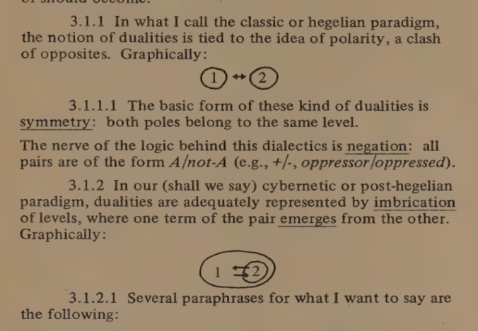

Gráficos en “Not one not two” (Varela, 1976)[^4]

En “Not one not two”, Varela especifica las tres propiedades principales que “caracterizan a un observador”, a saber:

> (…) “(i) capacidad de indicación: para establecer límites, para idear nodos, sistemas, para tener criterios. (ii) capacidad para el tiempo: cortar una red e iniciar una secuencia, calcular a través de un proceso, aproximar la estabilidad de un todo. (iii) capacidad de acuerdo: externalizar, sincronizarse con otros observadores, reproducir las distinciones de otros y seguir los patrones temporales correspondientes.” (Varela, 1976, p. 65)

Desde sus aproximaciones a la noción de autorreferencia, Varela exploró una concepción del observador que excedió el planteo fundado únicamente en la “distinción” de Spencer-Brown, las propiedades (ii) y (iii) producen competencias distintas, dad que se localizan en un tiempo y en relación con otros observadores.

¿De qué modo transforma estas relaciones analíticas en una consideración más amplia en torno a la experiencia?

> (…) “El quid de la cuestión radica en que existe una asimetría entre la consideración de las mentes de los demás y la de la mía. Las mentes de los demás pueden explicarse mediante algún paradigma descriptivo y nomológico (es decir, nuestra elección de un patrón conversacional, etc.). Mi mente sigue siendo algo diferente que no se agota en esa descripción; queda un residuo, un remanente que podemos llamar la experiencia de la mente, el sentido del yo. Curiosamente, tanto la tradición analítica (es decir, Feigl y sus seguidores) como la fenomenológica (es decir, Merleau-Ponty) coinciden en este punto. Mientras exista tal remanente en la descripción que la mente hace de las mentes, este sentido del yo que escapa a cualquier red descriptiva, la relación mente-cuerpo sigue siendo un problema.” (Varela, 1976, p. 66)

Dormir, soñar y morir, tres preguntas sobre las que Varela indagó en sus investigaciones, vinculando sus estudios sobre la conciencia con otras disciplinas. Pero en esta imbricación, entre la totalidad/partes de la totalidad, en esta relación que suspende las dualidades, existe un desplazamiento de la pregunta; desde el lenguaje (en sus descripciones de operaciones, el cálculo autorreferencial) a otros modos de observar estos procesos, sea desde la neurofenomenología o el enactivismo. Este desplazamiento que cuestiona los “reduccionismos” de la ciencia tradicional, conlleva una dimensión discursiva

La corporeización del proceso abductivo como modo de razonar, sujeta la descripción de operaciones en la observación, a sistemas no lineales. Las diferencias entre las lógicas de los seres vivientes, entre sistemas psíquicos y sociales, no puede ser “reducida”; dado que se corresponde con un *trayecto histórico de acoplamientos* entre sistemas y entornos en distintos niveles. Si seguimos a Stephen Jay Gould, el mismo descubrimiento del lenguaje como capacidad o competencia humana es una “puntuación” fuera del equilibrio, una extraordinaria contingencia en el extenso trayecto evolutivo. ¿Puede ignorar la teoría social, con el rigor de fundar una epistemología sobre la observación, el tiempo histórico que advierte la teoría de la evolución? Del otro lado de la indagación sobre la historicidad del “mundo”, sobre la evolución en las maneras de descripción, se figura la corporalidad que regula entre el Ego y No-Ego, que reconstruye distancias productivas, reconocimientos que transforman a partir de “diferencias de diferencias”. En Varela, en su oposición a la representación, se desarrolla la noción de “enacción”. Veamos el siguiente párrafo:

> (…) “Proponemos el término enactivo para este nuevo enfoque. En el programa enactivo, cuestionamos explícitamente el supuesto — predominante en las ciencias cognitivas— de que la cognición consiste en la representación de un mundo que es independiente de nuestra aptitud perceptiva y cognitiva a través de un sistema cognitivo que existe independientemente del mundo.”

Siguiendo a Francisco Varela, (...) "ya nos hemos apartado de la habitual idea de un observador abstracto e incorpóreo que, como una entidad cognitiva que desciende en paracaídas en un mundo preconfigurado, se topa con la materia como una categoría separada e independiente. Aquí, como en la fenomenología de Merleau-Ponty, nuestro encuentro con lo físico ya está situado y corporizado. La materia se describe en forma experiencial." (Varela et al., 1997, p. 89) ¿Cómo será posible el diálogo que anuncian? ¿Las máquinas pueden *soñar*? ¿Qué es *dialogar*? ¿Cómo se diferencia la naturaleza de las interacciones entre máquinas y seres humanos, en relación a este tópico?

Para Francisco Varela, esta circulación entre la mente computacional y la mente fenomenológica resulta fundamental. Observemos el siguiente pasaje:

> (…) “la verdadera cuestión aquí es la relación entre la mente computacional y la mente fenomenológica. Es decir, el término técnico fenomenología, a lo largo de mi conferencia, por favor entiéndanlo como sinónimo de acceso directo a la experiencia humana.” En sus palabras, (…) “lo que necesitamos, y no es tan difícil de encontrar, es construir un pasaje o una circulación entre estas dos formas de mente: la computacional y la fenomenológica, en lugar de considerarlas como resueltamente opuestas o imposibles de fusionar o separadas para siempre, la famosa frase "los gemelos nunca se encontrarán" El punto aquí es que sí, no solo pueden encontrarse, de hecho son dos aspectos de la misma realidad, pero para hacer que eso sea productivo más allá de las palabras, necesitamos valernos de nuevas herramientas, nuevas perspectivas y, particularmente, nuevos métodos. Los dos puntos centrales para mí son, por un lado, entender cómo podemos construir una circulación activa entre el lado computacional o biológico o neurobiológico y el lado fenomenológico.

> (…) “Y el segundo recurso esencial que necesitamos volver a poner sobre la mesa, que ha sido completamente descuidado, ciertamente dentro de la ciencia y en gran medida en la tradición occidental, es un método para el examen de la experiencia, es decir, un método fenomenológico adecuado.” (Varela, 1997, trad. propia).

# La observación creativa

> (…) “como lo subrayó Bateson, si no hay código (en el sentido estricto del término), para pasar del nivel de las relaciones corporales complementarias al lenguaje, tampoco hay pasaje codificado entre el cuerpo significante y el orden icónico, entre los íconos y el lenguaje: todo pasaje de un nivel a otro está afectado por la indeterminación, como el pasaje del sueño al relato del sueño: sabemos que el sueño y la puesta en palabras del mismo no son idénticos, pero, por definición, no podemos ni probar esa diferencia ni medir la distancia entre uno y otro.

> De la composición indeterminable de estos tres órdenes está hecho el sujeto significante.” (Verón, 1987, p. 160).

Concebir la autonomía constitutiva en-el-mundo de los observadores para-sí, es decir, *con un sentido para existir*, como posibilidad de auto-indicación con continuidad que permite la emergencia, la novedad, conlleva repensar la totalidad del sistema de observación. Porque no se trata de un programa formal que establece “distinciones”, programado *sólo* para ello; sino que se trata de una *búsqueda del sentido* *entre mundos*, con variaciones en los modos de acceso a la experiencia, con diferencias en los modos de auto organización que los propios seres vivos, en comunidad, transitan lo largo de sus vidas. La fenomenología constituye la vía de acceso para indagar en estos tránsitos, inestables en sus descripciones, pero necesariamente humanos.

Esta perspectiva centrada en los “remanentes”, el sentido del yo, es directamente recuperada por Verón en el intercambio con Ford, aunque presenta una crítica.

> (…) “Desde un punto de vista realista, decir”estamos navegando el referente” es un error epistemológico. Porque la noción de referente reenvía al discurso, el referente no es algo del mundo, es algo-del-mundo-designado-por- algún-signo. El referente, pues, presupone el signo.

> Si el mundo se reduce a la referencia, el realismo está equivocado. Porque entonces [el mundo] = [el mundo del cual se dice algo]. No hay residuo no referenciable.

> Justamente, el realismo necesita un residuo, necesita presuponer que el mundo desborda la referencia: hay más mundo que mundo referenciado. Con lo cual caemos en el objeto absoluto: si el mundo no coincide con el mundo referenciable, hay algo del mundo que es por definición in- designable, que escapa a todo lenguaje. Sobre este punto, no es que no valga la pena discutir; no se puede, por definición, discutir.” (Ford y Verón, 2006)

En la réplica, Aníbal Ford en un registro informal e irónico, menciona “la tríada que Verón construye: realismo/constructivismo/enacción porque me parece que tenemos diversas concepciones de esta (faire-émerger según el traductor al francés de Conocer de Varela) y también su crítica a Jackobson por nombrador. Lo dejo a Eliseo pensando o enactuando.” Publicado inicialmente en el 2000, este texto sobre experiencia y discurso, escrito en el Tigre, permite visualizar la incidencia del pensamiento de Varela en su recepción local, de qué modo tenía efectos en la construcción de hipótesis. Recuperar esta escena informal, en contraste con sus investigaciones publicadas, también constituye un acto de diferenciación, sitúa en su propia escritura la validación de otro espacio, tiempo, otra circunstancia para volver sobre la abducción. Aplica la perspectiva sobre los remanentes a la tríada de Peirce. Verón lo expresa del siguiente modo:

> (…) “La primeridad es el aspecto más irreductible de la experiencia (la secundariedad se puede contar). Irreductible quiere decir aquí: toda transposición (por ejemplo verbal) de una primeridad (por ejemplo, una emoción) deja un residuo. Pero ese residuo no es inefable, no es la emoción”absoluta” o “pura”. Porque esa primeridad-residuo es ya un signo. Lo interesante de Peirce es que permite pensar que hay semiosis (primeras) irreductibles a otras semiosis (terceras) y viceversa.” (Ford y Verón, 2006)

[figure not shown]

La clarividencia, 1936 de René Magritte

Barrena (s. f.) en relación a la creatividad sostiene que (…) “se debe a un razonamiento lógico —abductivo— y en ese sentido es un proceso autocontrolado, pero es un razonamiento lógico peculiar que ejerce una forma de control limitado e indirecto (Peirce, 1998, CP 7.45, c.1907).” En este sentido, la autora agrega, explorando el pensamiento de Hausman, que “para que algo sea considerado nuevo en el sentido de creativo hace falta una diferencia en su inteligibilidad.” Por otra parte, Andacht se centra en la imaginación, entendido como (…) “un componente clave de nuestro *self* o proceso identitario concebido como un signo en desarrollo continuo, cuyo incremento en complejidad y en capacidad de comprensión de los otros y de nosotros mismos ocurre mediante encuentros comunicacionales.” (Andacht, 2008).

Resulta válido, antes de continuar al próximo punto, habilitar la pregunta acerca de las condiciones de reconocimiento en tanto fenómeno que adjudicamos a las “máquinas” todavía en nuestros días, restricciones que operan en torno a la capacidad de “sentir”, “dormir”, “soñar”, “nacer” y “morir”, no en términos metafóricos sino como *sentidos auto producidos* a partir de su propia existencia, *sentidos* con condición de autonomía. ¿Por qué si no pueden “dudar” serían capaces de conocer algo sobre el mundo? Y si “dudan”, ¿por qué debería asumir su razonamiento eficazmente válido en todas las situaciones? ¿Se trata más bien el pasaje de un juego lúdico a un juego generalizado, socialmente validado como necesario, indispensable e históricamente inédito? ¿Hasta qué punto pueden disociarse o no el discurso sobre la información de los procesos intelectuales, como “conocer”, “pensar”, “imaginar”, “crear”; ya no como recursión lógica de/en/para un sistema sino como mecanismos de funcionamiento discursivo en la legitimación social del dispositivo, en el reconocimiento activo que produce en sus propias operaciones de auto-reconocimiento, para y desde las lógicas socio-individuales?

Esta distinción resulta central para abordar la crítica de Eliseo Verón a Niklas Luhmann. A diferencia de Luhmann, Verón opta por la indeterminación a partir de recuperar el pensamiento ternario de Peirce (Verón, 2013).

> (…) “El observador situado en la interfaz producción/reconocimiento está activando procesos autopoiéticos de dos sistemas autónomos: el sistema de los medios y el sistema que Luhmann llama ‘psíquico’…y que es quizás preferible designar como el sistema del actor. El desfasaje producción/reconocimiento no es otra cosa que la interfaz donde el sistema de los medios, que opera como entorno de los actores, pone su propia complejidad a disposición de estos últimos, y recíprocamente: el sistema del actor, que opera como entorno del sistema de los medios, pone su complejidad a disposición del sistema de los medios. (…)

Observado/observante constituyen una distinción sobre un tercero, algo que siempre es recuperado en otro sitio como "explicaciones": el rol, la motivación, incluso los *pensamientos* del otro. Algo más inquietante persiste en una aplicación de la propuesta teórica de Luhmann: el orden de lo real. ¿Cuando algo observado es real o no?¿Cómo saber cuándo un observador dice algo cierto o no? ¿Los observadores no cuentan, no construyen sus propias narrativas? ¿Qué grado de observación podría enunciar algo *verdadero*?

Veamos lo que afirma Paul Watzlawick (Watzlawick y Krieg, 1995) con respecto al modelo de *colusión*:

> (...) "En la teoría de la comunicación, este modelo de relación se denomina *colusión*. Con ello se quiere indicar un arreglo sutil, un *quid pro quo*, un acuerdo en el plano de la relación (a lo mejor sin que se tenga idea de ello) por el que uno deja que el otro le confirme y ratifique como la persona que uno cree ser. El no iniciado podría preguntar aquí con razón, para qué se necesita entonces una pareja. La respuesta es sencilla: imagínese usted a una madre sin hijo, a un médico sin enfermos, a un jefe de Estado sin Estado. Esto no serían más que esquemas, por decirlo así, personas provisionales. Sólo cuando tenemos el papel que necesitamos, nos convertimos en «reales»; sin él estamos a merced de nuestros sueños que, como se sabe, son vanos. Pero ¿por qué tiene uno que estar dispuesto a desempeñar para nosotros este papel determinado?" (Watzlawick y Krieg, 1995, p. 42)

Si los sistemas socio-individuales son sistemas orgánicos, por lo tanto, la construcción de hábitos estará mediada por escenas propias de cada sistema, con un tiempo propio. Estas escenas para el aprendizaje no son estáticas, están en situación de cambio constante. No son percibidas como escenas sino como secuencias, dada la continuidad de la experiencia, pero requieren de niveles de complejidad sobre lo aprendido. Ahora bien, desde el nacimiento, el observador de primer grado reconoce en su madre una figura que lo convierte parte de una relación que él no controla, en tanto "hijo" tendrá sus observaciones distintas del mundo. La distinción formal de observadores, en la trama de la vida, queda sujeto a relaciones cualitativamente distantes al modelo analizado de Luhmann. Si nuestra llegada al mundo implica constituirnos como observadores observados, ¿cuál es el *origen* de los observadores de primer grado? Si es sólo un cambio de "posición" ¿no depende este cambio de convenciones, que necesariamente la convierten en primeridades de una terceridad? Si seguimos el modelo de Luhmann ¿No requeriríamos una teoría sobre el desarrollo de las *observaciones* en el dominio ontogenético y filogenético? Tal vez, en las ciencias cognitivas se pueda identificar una propuesta. Eliseo Verón se refiere a la lógica de los sistemas socio-individuales como sistemas orgánicos y allí resiste una de las ideas más persistentes: la cualidad viviente en-el-mundo, que a diferencia de volvernos una excepción de grados, nos vuelve sólo una especie más de un trayecto largo en la historia de la evolución, una maravillosa contingencia.

# Conclusiones

Charles Sanders Peirce en “¿Qué es un signo?” (Peirce, 1999) afirma que (…) "el símbolo puede decirle al hombre, como la esfinge de Emerson - De tu ojo soy la mirada." El límite no configura una distinción entre espacios "marcados", sino que configura, a través de la experiencia, la posibilidad de una capacidad.

Roland Barthes describe con un ejemplo esta experiencia:

> (...) "Lo que está contado no es una aventura, son *incidentes*: es necesario tomar esta palabra en el sentido más tenue, más púdico posible. El incidente, mucho menos fuerte que el accidente (pero tal vez más inquietante), es simplemente *lo que cae* dulcemente como una hoja sobre el tapiz de la vida, es ese pliegue ligero, fugitivo, aportado a la trama de los días, es lo que *apenas* puede ser notado: una especie de grado cero de la notación, justo lo que hace falta para poder escribir *alguna* cosa." (Barthes, 2012)

*Cualidades*. *Lo sentible*, no como operación formal, sino como *capacidad de sentir* en y a través de experiencias. “*Living is sense-making*”, escribió Francisco Varela. Intensidades, gustos, sabores. ¿Qué observadores automáticos, qué sistemas observantes, podrán *simular* este espacio de *n* grados de libertad? Veamos la interpenetración entre sistemas sociales y sistemas socio-individuales. ¿No son justamente las *estructuras de parentesco*, siguiendo a Lévi-Strauss, lo que permite un acoplamiento en el dominio ontogenético entre ambos sistemas? ¿De qué manera, sino a través de las relaciones, la especie ha preservado las escenas necesarias para el *aprendizaje cultural*?

El despliegue de las inferencias sobre doblar la carta, involucra no sólo a quién dobla, a quién escribió, sino a la misma definición de “carta”. ¿Por qué suponer que *es* una carta?

El niño finalizó. La consigna (creo) abandonada. Con dos pliegues más realizó un barco de papel. Una carta, significante, quedó en otro lugar. Había multiplicado las miradas en el vaivén del hacer. Lo empujó y lo puso a navegar. Una fuerza ficticia, como aquella propia de los sistemas no inerciales. Tal vez, un sueño inconcluso. En una clara rebeldía a sus "observadores", su *desfase* en un *sistema en rotación sobre sí mismo* tuvo nombre: "Efecto Coriolis". O bien, la autorreferencia como desvío discursivo.

De la primeridad a la terceridad posible en un sólo atisbo.

## Referencias

Andacht, F. (2008), «[Self y creatividad en el pragmatismo de C. S. Peirce: “La incidencia del instante presente en la conducta”](https://www.redalyc.org/articulo.oa?id=27904003)», *Utopía y Praxis Latinoamericana*, 13(40), 39-65.

Barrena, S. (s. f.), Charles S. Peirce. Razón creativa y educación, https://www.unav.es/gep/BarrenaUtopia.html.

Barthes, R. (2012), *El grado cero de la escritura*, Siglo XXI.

Ford, A., y E. Verón (2006), «[Sobre experiencia y discurso](https://journals.openedition.org/revestudsoc/21849)», *Revista de Estudios Sociales*, (24).

Legg, C., y J. Reynolds (2022), «Habits of mind: New insights for embodied cognition from classical pragmatism and phenomenology», *Symposia: Pragmatism and Phenomenology. A Metaphilosophical Reconsideration*, XIV(2).

Peirce, C.S. (1997), «Casos degenerados», en: F.C. Vevia (trad.), *Escritos filosóficos*, El Colegio de Michoacán, pp. 293-302.

—— (1998), *The essential Peirce: Selected philosophical writings*, vol. 2, Indiana University Press.

—— (1999), *¿Qué es un signo?*, Universidad de Navarra.

—— (2020), *[Logic of the future: Writings on existential graphs. Volume 1: History and applications](https://doi.org/10.1515/9783110649345)*, De Gruyter.

—— (2021), *[The logical tracts. Volume 2/1 of Logic of the Future](https://doi.org/10.1515/9783110651423)*, De Gruyter.

—— (2024), *[Lowell Lectures of 1903: A study edition](https://doi.org/10.3726/b21234)*, Peter Lang GmbH.

Pietarinen, A.-V. (ed.) (2022), *Logic of the future. Volume 1: History and applications (Peirceana, Vol. 1)*, De Gruyter.

—— (2024), *Pragmaticism (Logic of the Future, Vol. 3/1)*, De Gruyter.

Schaeffer, J.M. (2009), *El fin de la excepción humana*, Fondo de Cultura Económica.

Varela, F.J. (1975), «[A calculus for self-reference](https://doi.org/10.1080/03081077508960822)», *International Journal of General Systems*, 2(1), 5-24.

—— (1976), *Not one, not two*.

—— (1979), *Principles of biological autonomy*, North Holland.

—— (1997), *[Why a science of mind implies the transcendence of nature](https://www.youtube.com/watch?v=xhS9ffDcLOk)*, Conferencia, God & Computers: Minds, Machines, and Metaphysics Lecture Series, MIT Artificial Intelligence Lab.

—— (2000), *El fenómeno de la vida: Ensayos sobre la biología del conocer*, J. C. Sáez Editor.

Varela, F.J., E. Thompson, y E. Rosch (1997), *De cuerpo presente: Las ciencias cognitivas y la experiencia humana*, Gedisa.

Verón, E. (1987), «El cuerpo reencontrado», en: *La semiosis social: Fragmentos de una teoría de la discursividad (Colección El mamífero parlante)*, Gedisa.

—— (2013), *La semiosis social 2: Ideas, momentos, interpretantes*, Paidós.

Watzlawick, P., y P. Krieg (1995), *El ojo del observador: Contribuciones al constructivismo*, Gedisa.

## Notas

[^1]: Jean-Marie Schaeffer (Schaeffer, 2009) señala la ruptura *óntica* en el interior del orden de lo viviente (Schaeffer, 2009, p. 23), al afirmar una diferencia de naturaleza entre el hombre y el resto de los seres vivientes. (…) "a menudo las ciencias sociales se definen así mismas como antinaturalistas, pero en realidad su antinaturalismo es, por lo general, un simple antibiologismo: se trata de un antinaturalismo que remite a la definición del objeto y no al modo de acceso cognitivo. (Schaeffer, 2009, p. 25)
[^2]: En un reciente artículo, Catherine Legg y Jack Reynolds (Legg y Reynolds, 2022) formulan una crítica al enactivismo, advierten que “corrientes antiintelectualistas que formaron el pragmatismo y la fenomenología han desembocado en el enactivismo contemporáneo. Al mismo tiempo, argumentamos que el enactivismo aún no ha logrado resolver por completo los problemas creados por el intelectualismo en la filosofía moderna. El intelectualismo ha sido recientemente objeto de un intenso debate en la filosofía dominante, debido a las recientes y destacadas refutaciones de los conocidos argumentos antiintelectualistas de Ryle (1946) por parte de los «neointelectualistas» (Stanley y Williamson, 2001; Stanley, 2011). Sin embargo, el neointelectualismo ha sido ampliamente criticado (p. ej., Levy, 2017; Hetherington, 2011; Cath, 2011) sin que se vislumbre una solución. Creemos que estos debates están resultando intratables porque no se han involucrado sustancialmente con las fuentes originales del debate, tanto en el pragmatismo clásico (Dewey 1910) como en la fenomenología de Husserl y Heidegger, de la que Ryle se basó de manera encubierta (Thomasson 2002).”

    En el marco del presente trabajo, sólo nos interesa poner en relación aspectos teóricos de Varela que pueden ser vinculados con la obra de Peirce, teniendo en cuenta que el pensamiento de Varela también ha dejado abiertos distintos senderos a explorar, habiendo modificado las nociones centrales a lo largo del tiempo.
[^3]: Si bien no resulta de interés en este trabajo analizar los textos complementarios, cabe destacar que Gregory Bateson explicita la intención de explorar una apertura de relaciones entre el discurso científico y otras disciplinas. (…) “Espero que los miembros de la conferencia puedan coincidir desde el principio en que los viejos compromisos entre la religión «sobrenatural» y la ciencia «materialista» son el resultado de una falsa división y subproductos del encuentro entre una teología rudimentaria y una ciencia igualmente rudimentaria.”
[^4]: El análisis de los sistemas de notación utilizados por Francisco Varela, tres años después, en *Principles of biological autonomy* (Varela, 1979), en conjunto con artículos y documentos anteriores, permitiría explorar las correspondencias con otras formalizaciones. Este aspecto constituye un desafío para próximas investigaciones.
[^5]: En este punto, cabe mencionar una similitud con la tercera distinción con respecto a los índices que demarca Charles Sanders Peirce, al señalar que (…) “los índices pueden distinguirse de otros signos o representaciones por tres marcas características: primero, que no tienen un parecido significativo con sus objetos; segundo, que se refieren a individuos, unidades individuales, colecciones individuales de unidades o continuidades individuales; tercero, que dirigen la atención a sus objetos por una *compulsión ciega*.” (Peirce, 1998, CP. 2.306, cursivas propias).